# Correlation of Heath factors to BMI and Sleep Trouble.

## Preliminaries

```r
suppressPackageStartupMessages(library(tidyverse))
suppressPackageStartupMessages(library(NHANES))
```

# Task 1: Data Source

I will use the NHANES data set for this project `data(NHANES)`.

“This is survey data collected by the US National Center for Health Statistics (NCHS) which has conducted a series of health and nutrition surveys since the early 1960’s. Since 1999 approximately 5,000 individuals of all ages are interviewed in their homes every year and complete the health examination component of the survey. The health examination is conducted in a mobile examination center (MEC).”

# Task 2: Load and Tidy the Data

```r
data(NHANES)

columnsToKeep <- c('ID' , 'AgeDecade', 'Diabetes' , 'Gender', 'Race3'
                   , 'RegularMarij', 'SleepTrouble' , 'SurveyYr'
                   , 'HealthGen','Age', 'BMI', 'BPSysAve', 'BPDiaAve', 'DirectChol'
                   , 'Pulse', 'TotChol', 'SleepHrsNight', 'Weight')


# I have selected some columns from the data set and created
# a selected.table


# TIDYING

selected.table <- NHANES[,columnsToKeep]

# selected only Survey year 2011_12 so we can use Race3
selected.table <-  selected.table %>% dplyr::filter(SurveyYr == '2011_12')

# Going to look at those patients who are self-reported health as 'Good'
selected.table <-  selected.table %>% dplyr::filter(HealthGen == 'Good')

# keep complete cases
selected.table <- na.omit(selected.table)

write.csv(x = selected.table, file = 'selectedNHANES.csv')
```

I selected the following columns:

ID, AgeDecade, Diabetes, Gender, Race3, RegularMarij, SleepTrouble, SurveyYr, HealthGen, Age, BMI, BPSysAve, BPDiaAve, DirectChol, Pulse, TotChol, SleepHrsNight, Weight

I am including only year `2011_12`, and those patients who are reporting that they are in `good` health.

I am keeping only the complete cases.

# Task 3: Listing of My Tibble

```r
str(selected.table)
```

```
Classes 'tbl_df', 'tbl' and 'data.frame':   913 obs. of  18 variables:
 $ ID           : int  62172 62180 62205 62205 62205 62205 62208 62220 62222 62222 ...
 $ AgeDecade    : Factor w/ 8 levels " 0-9"," 10-19",..: 5 4 3 3 3 3 4 4 4 4 ...
 $ Diabetes     : Factor w/ 2 levels "No","Yes": 1 1 1 1 1 1 1 1 1 1 ...
 $ Gender       : Factor w/ 2 levels "female","male": 1 2 2 2 2 2 2 1 2 2 ...
 $ Race3        : Factor w/ 6 levels "Asian","Black",..: 2 5 5 5 5 5 3 2 5 5 ...
 $ RegularMarij : Factor w/ 2 levels "No","Yes": 1 1 1 1 1 1 1 1 1 1 ...
 $ SleepTrouble : Factor w/ 2 levels "No","Yes": 1 2 2 2 2 2 1 2 2 2 ...
 $ SurveyYr     : Factor w/ 2 levels "2009_10","2011_12": 2 2 2 2 2 2 2 2 2 2 ...
 $ HealthGen    : Factor w/ 5 levels "Excellent","Vgood",..: 3 3 3 3 3 3 3 3 3 3 ...
 $ Age          : int  43 35 28 28 28 28 38 31 32 32 ...
 $ BMI          : num  33.3 27.9 28.9 28.9 28.9 28.9 22.2 40.4 25 25 ...
 $ BPSysAve     : int  103 107 122 122 122 122 105 120 104 104 ...
 $ BPDiaAve     : int  72 66 87 87 87 87 59 71 73 73 ...
 $ DirectChol   : num  1.89 0.85 1.03 1.03 1.03 1.03 1.19 1.37 1.32 1.32 ...
 $ Pulse        : int  80 66 70 70 70 70 52 62 78 78 ...
 $ TotChol      : num  4.37 3.7 5.46 5.46 5.46 5.46 5.25 5.09 5.53 5.53 ...
 $ SleepHrsNight: int  8 7 6 6 6 6 5 6 7 7 ...
 $ Weight       : num  98.6 89 84.8 84.8 84.8 ...
 - attr(*, "na.action")=Class 'omit'  Named int [1:572] 1 23 24 26 27 28 29 30 31 37 ...
  .. ..- attr(*, "names")= chr [1:572] "1" "23" "24" "26" ...
```

```r
Hmisc::describe(selected.table)
```

```
selected.table

 18  Variables      913  Observations
---------------------------------------------------------------------------
ID
       n  missing distinct     Info     Mean      Gmd      .05      .10
     913        0      525        1    67038     3289    62720    63283
     .25      .50      .75      .90      .95
   64514    66959    69698    70956    71315

lowest : 62172 62180 62205 62208 62220, highest: 71833 71847 71868 71873 71911
---------------------------------------------------------------------------
AgeDecade
       n  missing distinct
     913        0        5

Value      10-19 20-29 30-39 40-49 50-59
Frequency     45   192   209   263   204
Proportion 0.049 0.210 0.229 0.288 0.223
---------------------------------------------------------------------------
Diabetes
       n  missing distinct
     913        0        2

Value         No   Yes
Frequency    863    50
Proportion 0.945 0.055
---------------------------------------------------------------------------
Gender
       n  missing distinct
     913        0        2

Value      female   male
Frequency     399    514
Proportion  0.437  0.563
---------------------------------------------------------------------------
Race3
       n  missing distinct
     913        0        6

```

[output cut: 93 more lines]

```
       n  missing distinct     Info     Mean      Gmd
     913        0        9    0.944    6.759    1.427

Value          3     4     5     6     7     8     9    10    12
Frequency      5    39    88   259   252   206    48    15     1
Proportion 0.005 0.043 0.096 0.284 0.276 0.226 0.053 0.016 0.001
---------------------------------------------------------------------------
Weight
       n  missing distinct     Info     Mean      Gmd      .05      .10
     913        0      381        1    85.87    23.83    55.22    59.60
     .25      .50      .75      .90      .95
   71.50    83.30    99.40   109.98   125.94

lowest :  39.0  40.8  41.9  42.9  44.0, highest: 149.8 156.4 162.2 164.9 184.5
---------------------------------------------------------------------------
```

The table has 913 rows and 18 columns.

# Task 4: Code Book

Code book of the selected date from NHANES data set.

[output not shown]

# Task 5: My Subjects

The data I have selected from the NHANES contains 913 rows of data from NHANES. NHANES can be treated, for educational purposes, as if it were a simple random sample from the American population. Ref: NHANES documentation obtained from `? NHANES`, and website (NHANES WEBSITE)[https://www.cdc.gov/nchs/nhanes/index.htm]

All subjects have self-reported health of `good`, and are part of the 2011_20112 survey, and are complete cases.

# Task 6: My Variables

Detailed description

[output not shown]

## Explore:

## Explore:

## Explore:

# Task 7: My Planned Linear Regression Model

So the continuous outcome will be `BMI`, and I am going to look for which factors from those that I have selected that have to do with weight blood pressure, cholesterol, how well they sleep, and for fun if Marijuana use affects diabetes (I have never heard if Marijuana has an effect), and of course if it differs between race. I will test for both `Age` and `AgeDecade`, but will only use 1 of the two if it gets used in the model

`BMI` ~ `Weight` + `BPSysAve` + `BPDiaAve` + (`Age` or `AgeDecade`) `Pulse` + `DirectChol` + `TotChol` + `SleepHrsNight` + `RegularMarij` + `Race3` + `Diabetes`

# Task 8: My Planned Logistic Regression Model

So the binary outcome will be `SleepTrouble`, and I am going to look for which factors from those that I have selected that have to do with weight blood pressure, cholesterol, how well they sleep, and for fun if Marijuana use affects diabetes (I have no idea about this), and of course if it differs between race. I will test for both `Age` and `AgeDecade`, but will only use 1 of the two if it gets used in the model.

`SleepTrouble` ~ `Weight` + `BPSysAve` + `BPDiaAve` + (`Age` or `AgeDecade`) `Pulse` + `DirectChol` + `TotChol` + `SleepHrsNight` + `RegularMarij` + `Race3` + `Diabetes`

# Task 9: Affirmation

This data meets all requirements for the project instructions, as it is the public NHANES data set. I am certain that it is completely appropriate for these data to be shared with anyone, without any conditions. There are no concerns about privacy or security.

– Peter Wilkinson

# Task 10: Analysis - Linear regression

```r
model.lm.01 <- lm(formula = BMI ~ Weight + BPSysAve + BPDiaAve +
                           Age + AgeDecade + Pulse + DirectChol +
                           TotChol + SleepHrsNight + RegularMarij +
                           Race3 + Diabetes, data = selected.table)

summary(model.lm.01)
```

```
Call:
lm(formula = BMI ~ Weight + BPSysAve + BPDiaAve + Age + AgeDecade +
    Pulse + DirectChol + TotChol + SleepHrsNight + RegularMarij +
    Race3 + Diabetes, data = selected.table)

Residuals:
    Min      1Q  Median      3Q     Max
-8.7994 -2.0223 -0.2287  1.7264 12.7062

Coefficients:
                 Estimate Std. Error t value Pr(>|t|)
(Intercept)      0.234800   1.666379   0.141 0.887977
Weight           0.267482   0.005606  47.717  < 2e-16 ***
BPSysAve         0.008415   0.008690   0.968 0.333104
BPDiaAve        -0.015585   0.011127  -1.401 0.161669
Age              0.080598   0.036023   2.237 0.025504 *
AgeDecade 20-29  0.343499   0.554838   0.619 0.536009
AgeDecade 30-39 -0.497937   0.758218  -0.657 0.511530
AgeDecade 40-49 -0.933277   1.050154  -0.889 0.374401
AgeDecade 50-59 -1.993437   1.368627  -1.457 0.145600
Pulse            0.028928   0.009221   3.137 0.001761 **
DirectChol       0.470997   0.317926   1.481 0.138835
TotChol          0.223975   0.109745   2.041 0.041557 *
SleepHrsNight   -0.019351   0.079654  -0.243 0.808111
RegularMarijYes -0.446617   0.233936  -1.909 0.056564 .
Race3Black       0.772227   0.531273   1.454 0.146425
Race3Hispanic    1.603425   0.545208   2.941 0.003357 **
Race3Mexican     1.799349   0.537323   3.349 0.000846 ***
Race3White       0.045910   0.438680   0.105 0.916673
Race3Other      -0.018452   0.757065  -0.024 0.980561
DiabetesYes      1.290500   0.470758   2.741 0.006241 **
---
Signif. codes:  0 '***' 0.001 '**' 0.01 '*' 0.05 '.' 0.1 ' ' 1

Residual standard error: 3.052 on 893 degrees of freedom
Multiple R-squared:  0.7917,    Adjusted R-squared:  0.7873
F-statistic: 178.7 on 19 and 893 DF,  p-value: < 2.2e-16
```

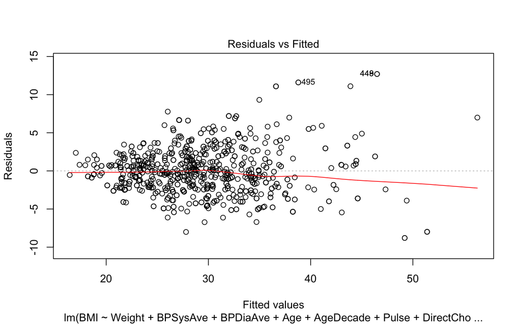

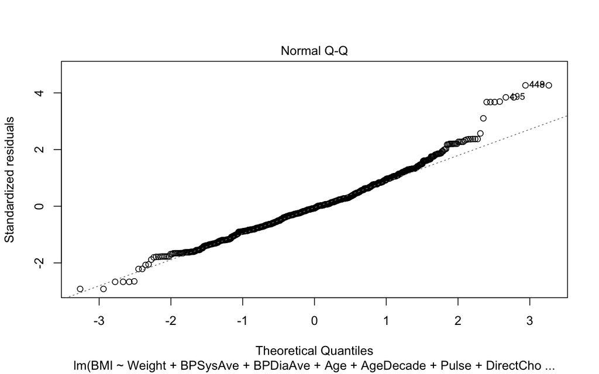

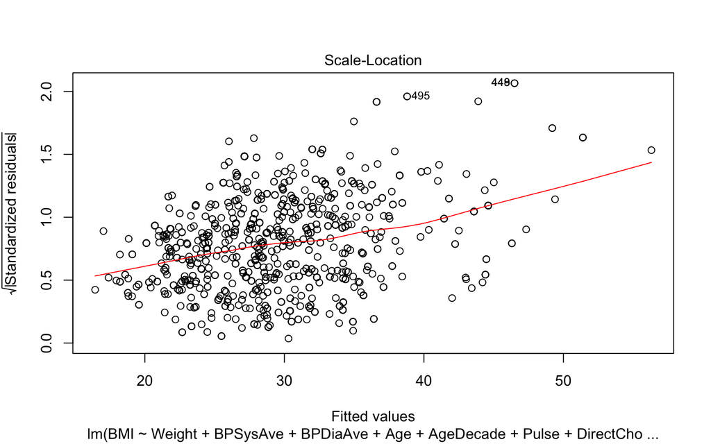

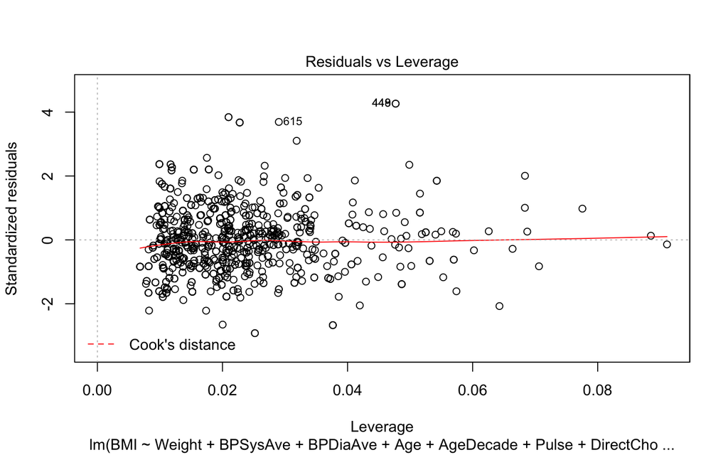

```r
plot(model.lm.01)
```

```r
rms::vif(model.lm.01)
```

```
         Weight        BPSysAve        BPDiaAve             Age
       1.437645        1.563340        1.563248       17.981768
AgeDecade 20-29 AgeDecade 30-39 AgeDecade 40-49 AgeDecade 50-59
       5.009561        9.943475       22.161891       31.847698
          Pulse      DirectChol         TotChol   SleepHrsNight
       1.113163        1.346523        1.247141        1.053426
RegularMarijYes      Race3Black   Race3Hispanic    Race3Mexican
       1.099751        2.626209        2.169450        2.463993
     Race3White      Race3Other     DiabetesYes
       4.422786        1.553799        1.124106
```

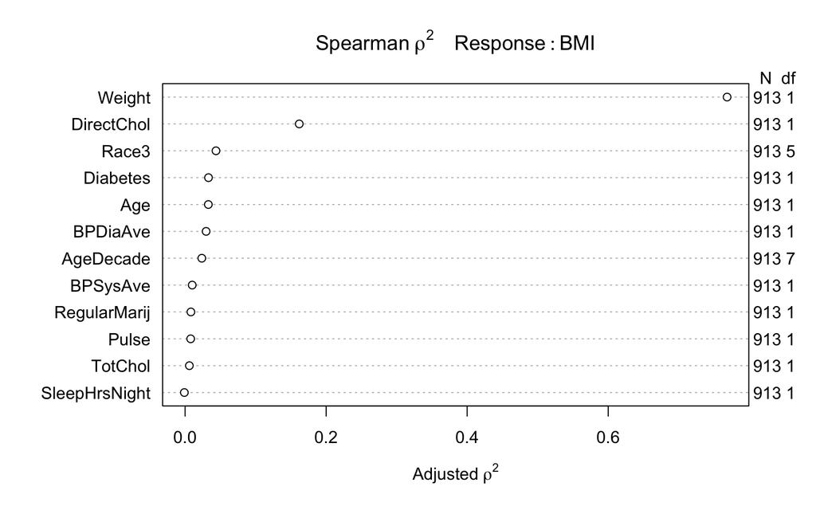

```r
plot(Hmisc::spearman2(BMI ~ Weight + BPSysAve + BPDiaAve +
                           Age + AgeDecade + Pulse + DirectChol +
                           TotChol + SleepHrsNight + RegularMarij +
                           Race3 + Diabetes, data = selected.table))
```

The Best predictors may be:

- Weight
- Age
- Pulse
- ToChol
- RegularMarij
- Race3Hispanic
- Race3Mexican
- Diabetes

```r
model.ols.01 <- rms::ols(formula = BMI ~ Weight + BPSysAve + BPDiaAve +
                           Age + AgeDecade + Pulse + DirectChol +
                           TotChol + SleepHrsNight + RegularMarij +
                           Race3 + Diabetes, data = selected.table)

model.ols.01
```

```
Linear Regression Model

 rms::ols(formula = BMI ~ Weight + BPSysAve + BPDiaAve + Age +
     AgeDecade + Pulse + DirectChol + TotChol + SleepHrsNight +
     RegularMarij + Race3 + Diabetes, data = selected.table)

                 Model Likelihood     Discrimination
                    Ratio Test           Indexes
 Obs     913    LR chi2    1432.44    R2       0.792
 sigma3.0525    d.f.            19    R2 adj   0.787
 d.f.    893    Pr(> chi2)  0.0000    g        6.488

 Residuals

     Min      1Q  Median      3Q     Max
 -8.7994 -2.0223 -0.2287  1.7264 12.7062


                  Coef    S.E.   t     Pr(>|t|)
 Intercept         0.2348 1.6664  0.14 0.8880
 Weight            0.2675 0.0056 47.72 <0.0001
 BPSysAve          0.0084 0.0087  0.97 0.3331
 BPDiaAve         -0.0156 0.0111 -1.40 0.1617
 Age               0.0806 0.0360  2.24 0.0255
 AgeDecade= 20-29  0.3435 0.5548  0.62 0.5360
 AgeDecade= 30-39 -0.4979 0.7582 -0.66 0.5115
 AgeDecade= 40-49 -0.9333 1.0502 -0.89 0.3744
 AgeDecade= 50-59 -1.9934 1.3686 -1.46 0.1456
 Pulse             0.0289 0.0092  3.14 0.0018
 DirectChol        0.4710 0.3179  1.48 0.1388
 TotChol           0.2240 0.1097  2.04 0.0416
 SleepHrsNight    -0.0194 0.0797 -0.24 0.8081
 RegularMarij=Yes -0.4466 0.2339 -1.91 0.0566
 Race3=Black       0.7722 0.5313  1.45 0.1464
 Race3=Hispanic    1.6034 0.5452  2.94 0.0034
 Race3=Mexican     1.7993 0.5373  3.35 0.0008
 Race3=White       0.0459 0.4387  0.10 0.9167
 Race3=Other      -0.0185 0.7571 -0.02 0.9806
 Diabetes=Yes      1.2905 0.4708  2.74 0.0062
```

```r
anova(model.ols.01)
```

```
                Analysis of Variance          Response: BMI

 Factor        d.f. Partial SS   MS           F       P
 Weight          1  2.121471e+04 2.121471e+04 2276.88 <.0001
 BPSysAve        1  8.737998e+00 8.737998e+00    0.94 0.3331
 BPDiaAve        1  1.827895e+01 1.827895e+01    1.96 0.1617
 Age             1  4.664428e+01 4.664428e+01    5.01 0.0255
 AgeDecade       4  6.890322e+01 1.722580e+01    1.85 0.1174
 Pulse           1  9.171085e+01 9.171085e+01    9.84 0.0018
 DirectChol      1  2.044948e+01 2.044948e+01    2.19 0.1388
 TotChol         1  3.880861e+01 3.880861e+01    4.17 0.0416
 SleepHrsNight   1  5.498966e-01 5.498966e-01    0.06 0.8081
 RegularMarij    1  3.396046e+01 3.396046e+01    3.64 0.0566
 Race3           5  3.489329e+02 6.978659e+01    7.49 <.0001
 Diabetes        1  7.001948e+01 7.001948e+01    7.51 0.0062
 REGRESSION     19  3.163061e+04 1.664769e+03  178.67 <.0001
 ERROR         893  8.320497e+03 9.317466e+00
```

```r
#ggplot(rms::Predict(model.ols.01))

#plot(rms::nomogram(model.ols.01))
```

The Best predictors may be:

- Weight
- Age
- Pulse
- ToChol
- RegularMarij
- Race3Hispanic
- Race3Mexican
- Diabetes

# Task 11: Analysis -Logistic Regression

```r
model.glmLO.01 <- glm(formula = SleepTrouble ~  Weight + BPSysAve + BPDiaAve + Age +
        AgeDecade +  Pulse + DirectChol + TotChol + SleepHrsNight +
        RegularMarij + Race3 + Diabetes, family = binomial, data = selected.table)


summary(model.glmLO.01)
```

```
Call:
glm(formula = SleepTrouble ~ Weight + BPSysAve + BPDiaAve + Age +
    AgeDecade + Pulse + DirectChol + TotChol + SleepHrsNight +
    RegularMarij + Race3 + Diabetes, family = binomial, data = selected.table)

Deviance Residuals:
    Min       1Q   Median       3Q      Max
-1.6850  -0.8309  -0.5314   1.0218   3.0543

Coefficients:
                 Estimate Std. Error z value Pr(>|z|)
(Intercept)     -2.559828   1.374824  -1.862  0.06261 .
Weight          -0.009484   0.004356  -2.177  0.02946 *
BPSysAve        -0.011213   0.007205  -1.556  0.11961
BPDiaAve         0.009984   0.009414   1.060  0.28892
Age              0.024878   0.028160   0.883  0.37700
AgeDecade 20-29  0.836577   0.509915   1.641  0.10088
AgeDecade 30-39  0.079583   0.649733   0.122  0.90251
AgeDecade 40-49  0.064731   0.863016   0.075  0.94021
AgeDecade 50-59  0.037824   1.098895   0.034  0.97254
Pulse            0.031574   0.007428   4.251 2.13e-05 ***
DirectChol       0.562566   0.243325   2.312  0.02078 *
TotChol         -0.088333   0.085733  -1.030  0.30286
SleepHrsNight   -0.365254   0.064166  -5.692 1.25e-08 ***
RegularMarijYes  0.328720   0.177678   1.850  0.06430 .
Race3Black       1.009428   0.531369   1.900  0.05748 .
Race3Hispanic    0.554526   0.562089   0.987  0.32387
Race3Mexican     0.463775   0.573822   0.808  0.41896
Race3White       1.852205   0.466131   3.974 7.08e-05 ***
Race3Other       1.267605   0.661917   1.915  0.05549 .
DiabetesYes      1.064274   0.338093   3.148  0.00164 **
---
Signif. codes:  0 '***' 0.001 '**' 0.01 '*' 0.05 '.' 0.1 ' ' 1

(Dispersion parameter for binomial family taken to be 1)

    Null deviance: 1103.50  on 912  degrees of freedom
Residual deviance:  962.31  on 893  degrees of freedom
AIC: 1002.3

Number of Fisher Scoring iterations: 5
```

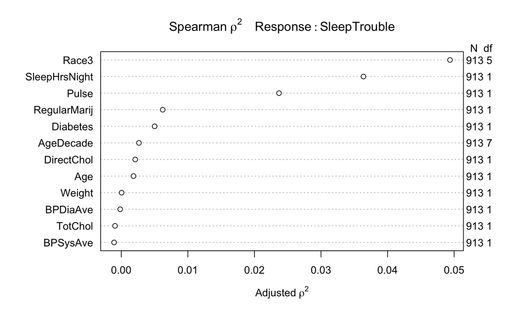

```r
plot(Hmisc::spearman2(SleepTrouble ~  Weight + BPSysAve + BPDiaAve + Age +
        AgeDecade +  Pulse + DirectChol + TotChol + SleepHrsNight +
        RegularMarij + Race3 + Diabetes, data = selected.table))
```

```r
#model.glmLO.01.aug <- broom::augment(model.glmLO.01, sim12, type.predict = "response")
```

Peter Wilkinson  
Case Western Reserve University  
peter.wilkinson@case.edu

2018-03-08